# R Workshop 2024

Hannah Damico

2024-09-11

# Understanding Your Data

## Reading & Viewing Data

Create a code chunk:  
Mac: Command + Option + i  
PC: Control + Alt + i

#### Read Data In

```r
# Is anything wrong with this?
# Yes it can't find the path because the data is in a different folder
# cytomegalovirus <- read_csv("~/bbc-research/RCR/R-Workshop-Sept2024/cytomegalovirus.csv")
# View(cytomegalovirus) # note that the document will not knit unless this is commented out


# What is different between these?
cyto_data <-
read_csv(file = "/varidata/researchtemp/hpctmp/r_basics_2024/cytomegalovirus.csv")
# str(cyto_data)
cyto_data2 <- read.csv(file = "/varidata/researchtemp/hpctmp/r_basics_2024/cytomegalovirus.csv")
# str(cyto_data2)
# read.csv will specify if you have an integer (no decimals)
```

#### What kind of object do we have?

Notice how we get a little more information than we need, this is due to the function we used to read in our data. “read_csv()” from the readr package assigns its own datatype called a tibble which can be treated more or less like a dataframe. Tibbles tend to load faster than a typical dataframe, though we likely won’t notice a difference with as small as this dataset is.

```r
# Understand our data more
## What kind of object is our data?
class(cyto_data)
```

```
## [1] "spec_tbl_df" "tbl_df"      "tbl"         "data.frame"
```

```r
class(cyto_data2)
```

```
## [1] "data.frame"
```

#### How many rows and columns does our data have?

```r
## What are the dimensions of our data? How many rows, how many columns
dim(cyto_data) # 64 rows, 26 columns
```

```
## [1] 64 26
```

```r
# We can also use
nrow(cyto_data) # to only count rows
```

```
## [1] 64
```

```r
ncol(cyto_data) # to only count columns
```

```
## [1] 26
```

#### What does our data structure look like?

```r
# Let's take a glimpse at our data
glimpse(cyto_data)
```

```
## Rows: 64
## Columns: 26
## $ ID                 <dbl> 1, 2, 3, 4, 5, 6, 7, 8, 9, 10, 11, 12, 13, 14, 15, …
## $ age                <dbl> 61, 62, 63, 33, 54, 55, 67, 51, 44, 59, 45, 57, 52,…
## $ sex                <chr> "1", "1", "0", "0", "0", "1", "1", "1", "0", "1", "…
## $ race               <chr> "0", "1", "1", "1", "1", "1", "1", "1", "0", "1", "…
## $ diagnosis          <chr> "acute myeloid leukemia", "non-Hodgkin lymphoma", "…
## $ diagnosis.type     <dbl> 1, 0, 0, 0, 0, 1, 1, 1, 0, 0, 0, 1, 1, 0, 1, 0, 1, …
## $ time.to.transplant <dbl> 5.16, 79.05, 35.58, 33.02, 11.40, 2.43, 9.59, NA, 4…
## $ prior.radiation    <dbl> 0, 1, 0, 1, 0, 0, 0, 0, 1, 0, 1, 0, 0, 1, 1, 0, 0, …
## $ prior.chemo        <dbl> 2, 3, 4, 4, 5, 0, 2, 0, 3, 2, 3, 2, 3, 3, 0, 5, 2, …
## $ prior.transplant   <dbl> 0, 0, 0, 0, 0, 0, 0, 1, 1, 0, 1, 0, 1, 1, 1, 0, 0, …
## $ recipient.cmv      <dbl> 1, 0, 1, 1, 1, 1, 1, 1, 1, 0, 0, 0, 1, 1, 0, 1, 1, …
## $ donor.cmv          <dbl> 0, 0, 1, 0, 1, 1, 1, 1, 1, 0, 1, 1, 1, 1, 1, 1, 1, …
## $ donor.sex          <dbl> 0, 1, 0, 1, 0, 1, 1, 0, 1, 0, 1, 0, 0, 0, 1, 0, 1, …
## $ TNC.dose           <dbl> 18.31, 4.26, 8.09, 21.02, 14.70, 4.29, 7.96, 15.63,…
## $ CD34.dose          <dbl> 2.29, 2.04, 6.97, 6.09, 2.36, 6.91, 3.66, 3.90, 7.0…
## $ CD3.dose           <dbl> 3.21, NA, 2.19, 4.87, 6.55, 2.53, 3.66, 7.27, 2.59,…
## $ CD8.dose           <dbl> 0.95, NA, 0.59, 2.32, 2.40, 0.86, 0.17, 1.95, NA, 1…
## $ TBI.dose           <dbl> 200, 200, 200, 200, 400, 200, 400, 400, 200, 400, 2…
## $ `C1/C2`            <dbl> 0, 1, 0, 0, 0, 0, 0, 0, 1, 1, 1, 1, 0, 1, 0, 1, 1, …
## $ aKIRs              <dbl> 1, 5, 3, 2, 6, 2, 1, 2, 2, 4, 2, 4, 5, 2, 2, 2, 1, …
## $ cmv                <dbl> 1, 0, 0, 0, 0, 1, 0, 0, 1, 0, 0, 0, 1, 1, 0, 1, 1, …
## $ time.to.cmv        <dbl> 3.91, 65.12, 3.75, 48.49, 4.37, 4.53, 2.99, 4.80, 2…
## $ agvhd              <dbl> 1, 0, 0, 1, 1, 1, 0, 0, 1, 0, 1, 1, 0, 0, 0, 0, 0, …
## $ time.to.agvhd      <dbl> 3.55, 65.12, 3.75, 28.55, 2.79, 3.88, 2.99, 4.80, 0…
## $ cgvhd              <dbl> 0, 0, 0, 1, 0, 0, 0, 0, 1, 1, 0, 0, 1, 1, 0, 1, 1, …
## $ time.to.cgvhd      <dbl> 6.28, 65.12, 3.75, 10.45, 4.37, 6.87, 2.99, 4.80, 6…
```

```r
# Notice that we can see the variable types
# dbl = double and is a number that can include a decimal
# Here's another option
str(cyto_data)
```

```
## spc_tbl_ [64 × 26] (S3: spec_tbl_df/tbl_df/tbl/data.frame)
##  $ ID                : num [1:64] 1 2 3 4 5 6 7 8 9 10 ...
##  $ age               : num [1:64] 61 62 63 33 54 55 67 51 44 59 ...
##  $ sex               : chr [1:64] "1" "1" "0" "0" ...
##  $ race              : chr [1:64] "0" "1" "1" "1" ...
##  $ diagnosis         : chr [1:64] "acute myeloid leukemia" "non-Hodgkin lymphoma" "non-Hodgkin lymphoma" "Hodgkin lymphoma" ...
##  $ diagnosis.type    : num [1:64] 1 0 0 0 0 1 1 1 0 0 ...
##  $ time.to.transplant: num [1:64] 5.16 79.05 35.58 33.02 11.4 ...
##  $ prior.radiation   : num [1:64] 0 1 0 1 0 0 0 0 1 0 ...
##  $ prior.chemo       : num [1:64] 2 3 4 4 5 0 2 0 3 2 ...
##  $ prior.transplant  : num [1:64] 0 0 0 0 0 0 0 1 1 0 ...
##  $ recipient.cmv     : num [1:64] 1 0 1 1 1 1 1 1 1 0 ...
##  $ donor.cmv         : num [1:64] 0 0 1 0 1 1 1 1 1 0 ...
##  $ donor.sex         : num [1:64] 0 1 0 1 0 1 1 0 1 0 ...
##  $ TNC.dose          : num [1:64] 18.31 4.26 8.09 21.02 14.7 ...
##  $ CD34.dose         : num [1:64] 2.29 2.04 6.97 6.09 2.36 6.91 3.66 3.9 7 2.52 ...
##  $ CD3.dose          : num [1:64] 3.21 NA 2.19 4.87 6.55 2.53 3.66 7.27 2.59 2.52 ...
##  $ CD8.dose          : num [1:64] 0.95 NA 0.59 2.32 2.4 0.86 0.17 1.95 NA 1.22 ...
##  $ TBI.dose          : num [1:64] 200 200 200 200 400 200 400 400 200 400 ...
##  $ C1/C2             : num [1:64] 0 1 0 0 0 0 0 0 1 1 ...
##  $ aKIRs             : num [1:64] 1 5 3 2 6 2 1 2 2 4 ...
##  $ cmv               : num [1:64] 1 0 0 0 0 1 0 0 1 0 ...
##  $ time.to.cmv       : num [1:64] 3.91 65.12 3.75 48.49 4.37 ...
##  $ agvhd             : num [1:64] 1 0 0 1 1 1 0 0 1 0 ...
##  $ time.to.agvhd     : num [1:64] 3.55 65.12 3.75 28.55 2.79 ...
##  $ cgvhd             : num [1:64] 0 0 0 1 0 0 0 0 1 1 ...
##  $ time.to.cgvhd     : num [1:64] 6.28 65.12 3.75 10.45 4.37 ...
##  - attr(*, "spec")=
##   .. cols(
##   ..   ID = col_double(),
##   ..   age = col_double(),
##   ..   sex = col_character(),
##   ..   race = col_character(),
##   ..   diagnosis = col_character(),
##   ..   diagnosis.type = col_double(),
##   ..   time.to.transplant = col_double(),
##   ..   prior.radiation = col_double(),
##   ..   prior.chemo = col_double(),
##   ..   prior.transplant = col_double(),
##   ..   recipient.cmv = col_double(),
##   ..   donor.cmv = col_double(),
##   ..   donor.sex = col_double(),
##   ..   TNC.dose = col_double(),
##   ..   CD34.dose = col_double(),
##   ..   CD3.dose = col_double(),
##   ..   CD8.dose = col_double(),
##   ..   TBI.dose = col_double(),
##   ..   `C1/C2` = col_double(),
##   ..   aKIRs = col_double(),
##   ..   cmv = col_double(),
##   ..   time.to.cmv = col_double(),
##   ..   agvhd = col_double(),
##   ..   time.to.agvhd = col_double(),
##   ..   cgvhd = col_double(),
##   ..   time.to.cgvhd = col_double()
##   .. )
##  - attr(*, "problems")=<externalptr>
```

```r
# Let's  print out our data this way
cyto_data
```

```
## # A tibble: 64 × 26
##       ID   age sex   race  diagnosis           diagnosis.type time.to.transplant
##    <dbl> <dbl> <chr> <chr> <chr>                        <dbl>              <dbl>
##  1     1    61 1     0     acute myeloid leuk…              1               5.16
##  2     2    62 1     1     non-Hodgkin lympho…              0              79.0
##  3     3    63 0     1     non-Hodgkin lympho…              0              35.6
##  4     4    33 0     1     Hodgkin lymphoma                 0              33.0
##  5     5    54 0     1     acute lymphoblasti…              0              11.4
##  6     6    55 1     1     myelofibrosis                    1               2.43
##  7     7    67 1     1     acute myeloid leuk…              1               9.59
##  8     8    51 1     1     acute myeloid leuk…              1              NA
##  9     9    44 0     0     multiple myelomas                0              43.4
## 10    10    59 1     1     chronic lymphocyti…              0              92.7
## # ℹ 54 more rows
## # ℹ 19 more variables: prior.radiation <dbl>, prior.chemo <dbl>,
## #   prior.transplant <dbl>, recipient.cmv <dbl>, donor.cmv <dbl>,
## #   donor.sex <dbl>, TNC.dose <dbl>, CD34.dose <dbl>, CD3.dose <dbl>,
## #   CD8.dose <dbl>, TBI.dose <dbl>, `C1/C2` <dbl>, aKIRs <dbl>, cmv <dbl>,
## #   time.to.cmv <dbl>, agvhd <dbl>, time.to.agvhd <dbl>, cgvhd <dbl>,
## #   time.to.cgvhd <dbl>
```

```r
# try running this in your console and see what happens!
```

#### Can we see the top and bottom of our dataframe?

```r
# Let's look at the first 10 rows of our data
head(cyto_data, n= 10)
```

```
## # A tibble: 10 × 26
##       ID   age sex   race  diagnosis           diagnosis.type time.to.transplant
##    <dbl> <dbl> <chr> <chr> <chr>                        <dbl>              <dbl>
##  1     1    61 1     0     acute myeloid leuk…              1               5.16
##  2     2    62 1     1     non-Hodgkin lympho…              0              79.0
##  3     3    63 0     1     non-Hodgkin lympho…              0              35.6
##  4     4    33 0     1     Hodgkin lymphoma                 0              33.0
##  5     5    54 0     1     acute lymphoblasti…              0              11.4
##  6     6    55 1     1     myelofibrosis                    1               2.43
##  7     7    67 1     1     acute myeloid leuk…              1               9.59
##  8     8    51 1     1     acute myeloid leuk…              1              NA
##  9     9    44 0     0     multiple myelomas                0              43.4
## 10    10    59 1     1     chronic lymphocyti…              0              92.7
## # ℹ 19 more variables: prior.radiation <dbl>, prior.chemo <dbl>,
## #   prior.transplant <dbl>, recipient.cmv <dbl>, donor.cmv <dbl>,
## #   donor.sex <dbl>, TNC.dose <dbl>, CD34.dose <dbl>, CD3.dose <dbl>,
## #   CD8.dose <dbl>, TBI.dose <dbl>, `C1/C2` <dbl>, aKIRs <dbl>, cmv <dbl>,
## #   time.to.cmv <dbl>, agvhd <dbl>, time.to.agvhd <dbl>, cgvhd <dbl>,
## #   time.to.cgvhd <dbl>
```

```r
# what about the last 10 rows?
tail(cyto_data, n = 10)
```

```
## # A tibble: 10 × 26
##       ID   age sex   race  diagnosis           diagnosis.type time.to.transplant
##    <dbl> <dbl> <chr> <chr> <chr>                        <dbl>              <dbl>
##  1    55    61 1     1     acute myeloid leuk…              1               2.53
##  2    56    57 1     1     acute myeloid leuk…              1               4.5
##  3    57    61 0     1     acute myeloid leuk…              1               4.01
##  4    58    57 0     1     myelofibrosis                    1               5.68
##  5    59    58 1     1     non-Hodgkin lympho…              0              70.7
##  6    60    41 0     1     non-Hodgkin lympho…              0             152.
##  7    61    57 0     1     acute myeloid leuk…              1              33.5
##  8    62    61 1     1     myelodysplastic sy…              1               8.94
##  9    63    50 1     1     myeloproliferative…              1             174.
## 10    64    64 0     1     acute myeloid leuk…              1              24.4
## # ℹ 19 more variables: prior.radiation <dbl>, prior.chemo <dbl>,
## #   prior.transplant <dbl>, recipient.cmv <dbl>, donor.cmv <dbl>,
## #   donor.sex <dbl>, TNC.dose <dbl>, CD34.dose <dbl>, CD3.dose <dbl>,
## #   CD8.dose <dbl>, TBI.dose <dbl>, `C1/C2` <dbl>, aKIRs <dbl>, cmv <dbl>,
## #   time.to.cmv <dbl>, agvhd <dbl>, time.to.agvhd <dbl>, cgvhd <dbl>,
## #   time.to.cgvhd <dbl>
```

## New Skills

### Identify Variable Types

Now that we have our example data lined up, let’s look at some of the variables and understand their structure.

```r
# Let's introduce a new function to look at the names of our variables
colnames(cyto_data)
```

```
##  [1] "ID"                 "age"                "sex"
##  [4] "race"               "diagnosis"          "diagnosis.type"
##  [7] "time.to.transplant" "prior.radiation"    "prior.chemo"
## [10] "prior.transplant"   "recipient.cmv"      "donor.cmv"
## [13] "donor.sex"          "TNC.dose"           "CD34.dose"
## [16] "CD3.dose"           "CD8.dose"           "TBI.dose"
## [19] "C1/C2"              "aKIRs"              "cmv"
## [22] "time.to.cmv"        "agvhd"              "time.to.agvhd"
## [25] "cgvhd"              "time.to.cgvhd"
```

Categorical variables: nominal  
ordinal

```r
# categorical variables are characters or strings, like we learned last week
# we consider two kinds of these
# some where order matters and some where it doesn't
# A nominal variable is a categorical variable where there's no particular order
# In our data, this could be diagnosis
# here's a new function that shows us the total counts of observations in each group
table(cyto_data$diagnosis)
```

```
##
## acute lymphoblastic leukemia       acute myeloid leukemia
##                            1                           12
##              aplastic anemia chronic lymphocytic leukemia
##                            1                            5
##     chronic myeloid leukemia            congenital anemia
##                            4                            1
##             Hodgkin lymphoma            multiple myelomas
##                            3                            7
##     myelodysplastic syndrome                myelofibrosis
##                            9                            4
##  myeloproliferative disorder         non-Hodgkin lymphoma
##                            1                           11
##         renal cell carcinoma
##                            4
```

```r
# but this could also mean prior radiation
# this variable is an instance of a binary variable where R is understanding its structure to be numeric, but we recognize that these are really two groups of 1 = "Yes prior radiation" and 0 = "No prior radiation". This is also an example of a logical variable type where 1 = TRUE and 0 = FALSE
table(cyto_data$prior.radiation)
```

```
##
##  0  1
## 52 11
```

```r
# categorical variables variables are defaulted to sort into alphabetical order by R
# Want to see something wacky? This might be fun to explore on your own, but we won't go into details today
# share this with them depending on time left
v <- c("1", "8", "6", "2", "33", "115")
sort(v)
```

```
## [1] "1"   "115" "2"   "33"  "6"   "8"
```

ordinal variables

```r
# What about when our variable does have order?
# take prior.chemo for example
# number of prior chemo treatments in patients ranges from 0-8
# This means that 8 treatments differs from 0 treatments on an incremental level
# We like to give R some help in handling variables like this by changing them to something called a factor
# A factor is similar to a character string variable, how
table(cyto_data$prior.chemo)
```

```
##
##  0  1  2  3  4  5  7  8
## 10 15 17  8  6  5  1  1
```

```r
# let's save this variable as a factor so that R knows we want this order to matter
# best way to achieve this:
cyto_data$prior.chemo <- factor(cyto_data$prior.chemo, levels = 0:8)
# c(0,1,2,3,4,5,6,7,8)
# let's check it
# revisit the str() function
str(cyto_data$prior.chemo)
```

```
##  Factor w/ 9 levels "0","1","2","3",..: 3 4 5 5 6 1 3 1 4 3 ...
```

Notice how prior.chemo is a variable of numbers that can be treated as a categorical variable. This happens sometimes! This is why it’s important to pay attention to your data.

Continuous Variables

```r
# continuous variables can take on an infinite number of values within a range
# think about age, the average lifespan of a human is around 82 years (this is extremely general considering there are so many factors that play into this)
# So we can think of age range overall to be 1 day - 82 years (29,930 days)
# Maybe we have a study limited to only women in their 50s
# then our age range might be between 50-59
# how can we get a quick check?
summary(cyto_data$age)
```

```
##    Min. 1st Qu.  Median    Mean 3rd Qu.    Max.
##   29.00   46.00   55.00   67.17   61.00 1000.00
```

```r
# Another example, notice how we have NAs as an added column
# Notice the range change
summary(cyto_data$CD3.dose)
```

```
##    Min. 1st Qu.  Median    Mean 3rd Qu.    Max.    NA's
##   1.080   3.047   3.975   4.285   5.490   8.180       4
```

### Variable Selection

Today we’re going to focus on a handful variables of interest: ID - patient ID  
TNC.dose - dose amount of TNC cells  
CD3.dose - dose amount of CD3 cells  
age - numeric  
prior.chemo - ordinal, number of prior chemo treatments  
prior.radiation - binary, nominal variable, number of prior radiation treatments

You’re going to learn two new things here:  
select() function from dplyr package  
pipe operator %>%  
Mac shortcut: Command + shift + M  
PC shortcut: Cntrl + shift + M

```r
# the order you select the variables designates how you see them in the dataframe
# we want to save a new dataframe to preserve the variable selection
# here, we're using the dplyr package function select
cyto_data_selected <- cyto_data %>%
  select(ID, TNC.dose, CD3.dose, age, prior.chemo, prior.radiation)
```

## Missing Value and Outlier Detection

#### Missing Data

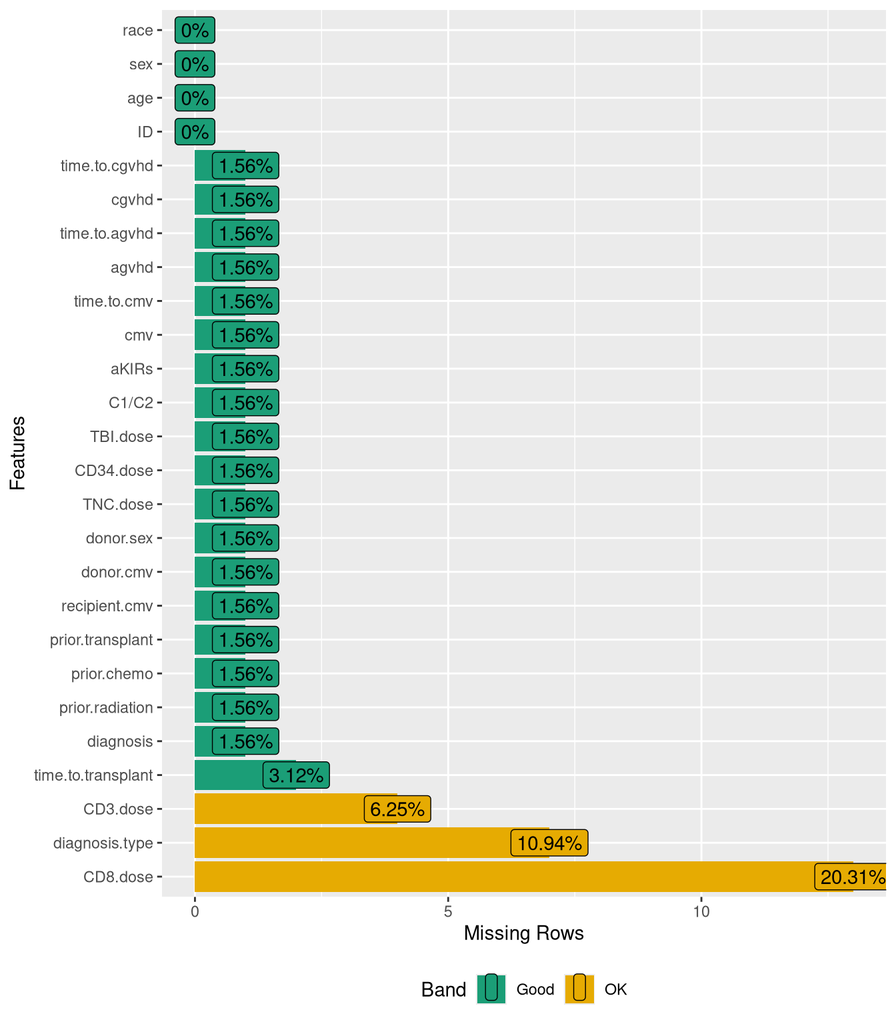

```r
library(DataExplorer) # here's a new package!
plot_missing(cyto_data)
```

```r
# let's look at CD8.dose more closely
summary(cyto_data$CD8.dose)
```

```
##    Min. 1st Qu.  Median    Mean 3rd Qu.    Max.    NA's
##   0.160   0.800   1.200   1.299   1.615   3.190      13
```

```r
# we have 13 missing values
# how we handle those depends on a multitude of factors and could be its own lecture
# today, we'll just note that we shouldn't completely ignore missingness and keep it in mind for the future
```

Table function in R https://www.rdocumentation.org/packages/base/versions/3.6.2/topics/table

```r
# go back to the prior.radiation variable
# lets look at a table of those binary values again
table(cyto_data_selected$prior.radiation)
```

```
##
##  0  1
## 52 11
```

```r
# now show them what it looks like with this in there
# , useNA = "ifany" <- this is way more intuitive?? lol
# , exclude = "ifany"
```

We don’t always want to filter missing values out immediately because we could lose vital information that didn’t need to be removed.

#### Outlier Detection

```r
# lets pick a variable that we usually want to understand
# age for instance
# look at the summary again,
# point out the max age range, 1000? what? no vampires in this data
# in honor of spooky season
summary(cyto_data$age)
```

```
##    Min. 1st Qu.  Median    Mean 3rd Qu.    Max.
##   29.00   46.00   55.00   67.17   61.00 1000.00
```

```r
# remember that we have to save a new object if we want the filter to stick around, similar to select
cyto_data_filtered <- cyto_data_selected %>% filter(age < 1000)

summary(cyto_data_filtered$age)
```

```
##    Min. 1st Qu.  Median    Mean 3rd Qu.    Max.
##   29.00   46.00   55.00   52.37   61.00   67.00
```

```r
# this doesn't always work, maybe we have an age in the 3rd quartile that's still dragging our age distribution too wide. This is why we need to double check that our filtration is doing what we ask of it
```

```r
# TELL THEM NOT TO FOLLOW THIS CODE
ex_outlier_plot <- cyto_data %>%  ggplot() + geom_point(aes( y = CD8.dose, x = CD34.dose)) + theme_bw()
# saveRDS(ex_outlier_plot, "example_outlier_plot.rds")
```

## Let’s do some plots!

**LEARNING SOMETHING NEW**

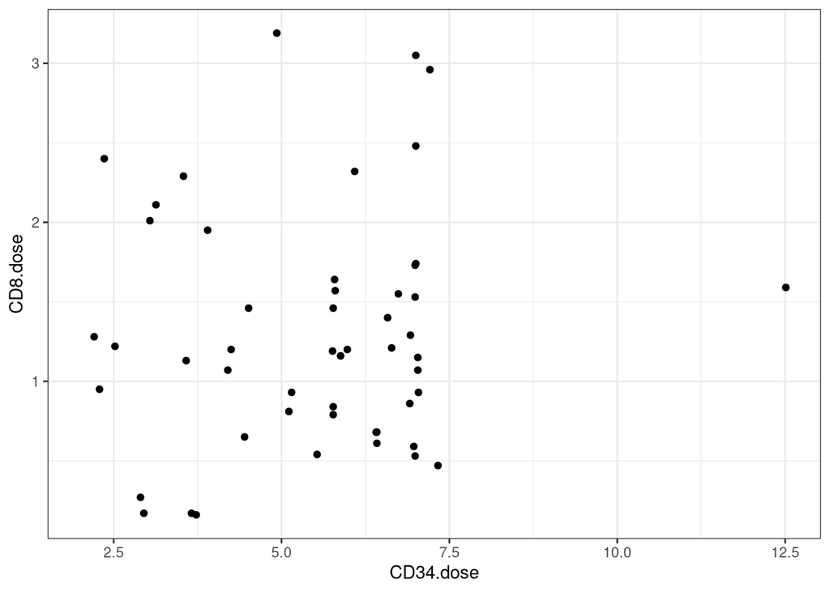

```r
# when we want to make a plot with more aesthetics than base R provides, we can use the ggplot2
# notice that my lines within my ggplot always end with a +
# R will not allow you to being a line with a pip or a + because it gets confused what you're asking for
# start with your data
# this tells R to access information from this dataframe
  # next, give R a function to execute, when we want to  make a plot, we need to tell R to start
    # next use your plot rendering function
  # geom_point() tells us what kind of plot we want ggplot to make with our data
  # next we have an extra step
  # if we want to use variables that come from our data, we need to give it an extra function
  # this is called an aesthetic and is used in your plot type function
cyto_data %>%
  ggplot(aes(x = CD34.dose, y = CD8.dose)) +
  geom_point() +
  theme_bw()
```

```r
# I'm adding theme_bw() as an example of how you can change the default theme. This one shows the values a little better in my opinion
```

What if we wanted to estimate a line of best fit through this data? Now this is just a best guess type of line using a linear model method, but notice how that straggler had an effect on where that line went. This is something to pay attention to in your data before you model.

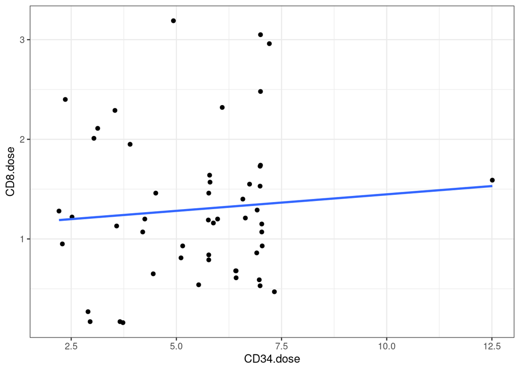

```r
cyto_data %>%
  ggplot(aes(x = CD34.dose, y = CD8.dose)) +
  geom_point() +
  geom_smooth(method = "lm", se = F) +
  theme_bw()
```

#### Cateorical plotting

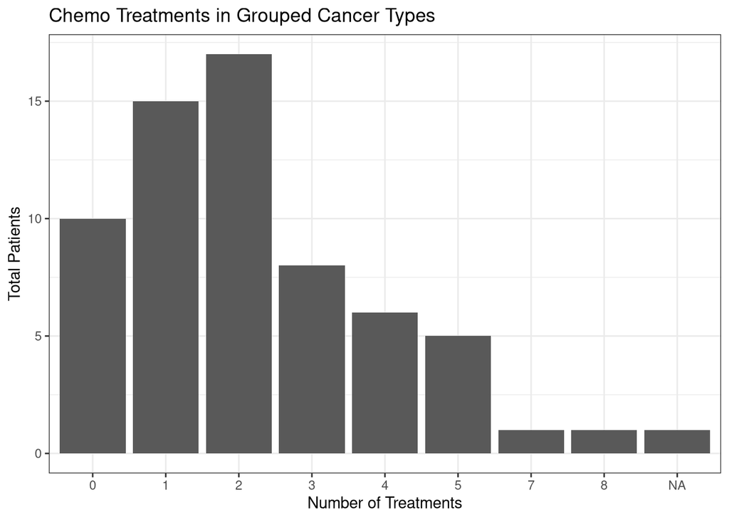

```r
# how about making a plot for those categorical variables?
# geom_point needs at least 1 continuous variable, but geom_bar can take

cyto_data %>%
  ggplot(aes(x = prior.chemo)) +
  geom_bar() +
  ggtitle("Chemo Treatments in Grouped Cancer Types") +
  xlab("Number of Treatments") +
  ylab("Total Patients") +
  theme_bw()
```

New content: %in% function

This function is asking R to only grab information from a that is contained in b

a %in% b

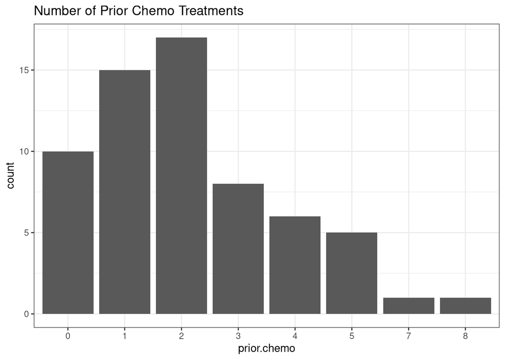

```r
# notice how we have a little missing value group there
# in this case, let's do some work to prior.chemo
# we only want to show the levels 0-8 of this factor, so what function can we utilize here?

cyto_data %>%
  filter(prior.chemo %in% 0:8)  %>%
  ggplot(aes(x = prior.chemo)) +
  geom_bar() +
  ggtitle("Number of Prior Chemo Treatments") +
  theme_bw()
```

Next, why don’t we add a little filled color to this. Maybe we’re interested in the number of prior chemo treatments split by cancer diagnosis type

With barchart, the fill option will let you fill those bars up with color rather than just an outline

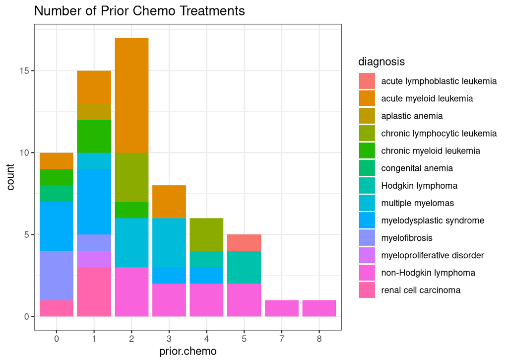

```r
cyto_data %>%
  filter(prior.chemo %in% 0:8)  %>%
  ggplot(aes(x = prior.chemo,
             fill = diagnosis)) +
  geom_bar() +
  ggtitle("Number of Prior Chemo Treatments") +
  theme_bw()
```

## Analysis

Code this line by line Note that we *do* care about the missing values in prior radiation, but for now, we want a plot that excludes these from our groups

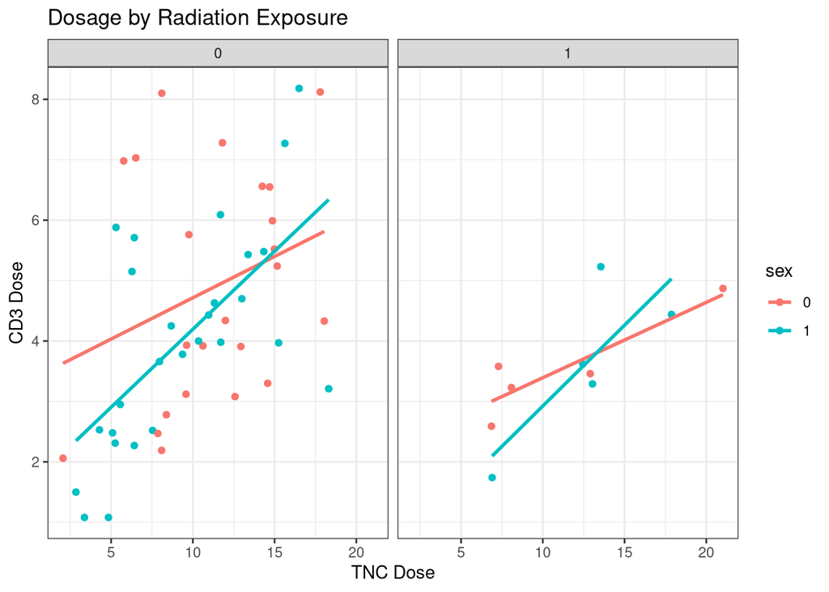

```r
cyto_data %>%
  filter(prior.radiation %in% c(0,1)) %>%
  ggplot(aes(x = TNC.dose, y = CD3.dose, color = sex)) +
  geom_point() +
  geom_smooth(method = "lm", se = F) +
  facet_grid(.~prior.radiation) +  # this will be new!
  xlab("TNC Dose") + ylab("CD3 Dose") + ggtitle("Dosage by Radiation Exposure") +
  theme_bw()
```

##### What have you learned today?

Outlier  
Missing values  
Different variable types  
Categorical vs. Continuous variable  
Nominal vs. Ordinal  
Factor vs. Character  
Advantages to a factor vs. a character  
Tidyverse – decide which packages address your project goals  
Readr: read_csv - done  
Dplyr: filter, select, mutate, group_by/summarize, arrange  
ggplot: point, boxplot, histogram, barchart